# Multivariate Analysis_HW2

DW

2024-04-06

Question 5.18:(a) We know the test statistic is the Hotelling T-square:
$$T^2 = n(\bar{X} - \mu_0)^T
S^{-1} (\bar{X} - \mu_0)$$

```r
data1 = read.csv("C:/Users/Synlim/Desktop/hw_data/T5-2.csv",header = F)
colnames(data1) = c("score1", "score2", "score3")
head(data1)
```

```
##   score1 score2 score3
## 1    468     41     26
## 2    428     39     26
## 3    514     53     21
## 4    547     67     33
## 5    614     61     27
## 6    501     67     29
```

```r
mu0 <- c(500,50,30)
#install.packages('ICSNP')
library(ICSNP)
library(MASS)
# Perform Hotelling's T-squared test
hotelling_test <- HotellingsT2(data1, mu = mu0)

# Print the results
print(hotelling_test)
```

```
##
##  Hotelling's one sample T2-test
##
## data:  data1
## T.2 = 72.706, df1 = 3, df2 = 84, p-value < 2.2e-16
## alternative hypothesis: true location is not equal to c(500,50,30)
```

As p-value < 2.2e-16, we can reject H0 at significant level 0.05

Question 5.18:(b)

```r
# Calculate the sample mean vector and covariance matrix
sample_mean <- colMeans(data1)
cov_matrix <- cov(data1)

# Perform eigen decomposition
eigen_result <- eigen(cov_matrix)

# Calculate the degrees of freedom
n <- nrow(data1)
p <- ncol(data1)
df <- n - p

# Calculate the critical value of F at the 95% confidence level
F_critical <- qf(0.95, df1 = p, df2 = df)
print(F_critical)
```

```
## [1] 2.713227
```

```r
# Calculate the critical value of T-squared
T2_critical <- ((n - 1) * p * F_critical) / (n - p)
print(T2_critical)
```

```
## [1] 8.333483
```

```r
# Scale the square roots of the eigenvalues to get the axes lengths
axes_lengths <- sqrt(eigen_result$values * T2_critical / n)

# The eigenvectors are the directions of the axes
axes_directions <- eigen_result$vectors

# Print the lengths and directions of the axes(eigenvectors)
print(axes_lengths)
```

```
## [1] 23.729998  2.472768  1.182500
```

```r
print(axes_directions)
```

```
##            [,1]         [,2]         [,3]
## [1,] 0.99390539  0.103731534 -0.037307396
## [2,] 0.10344339 -0.994589227 -0.009577815
## [3,] 0.03809906 -0.005660238  0.999257936
```

Question 5.18(c):

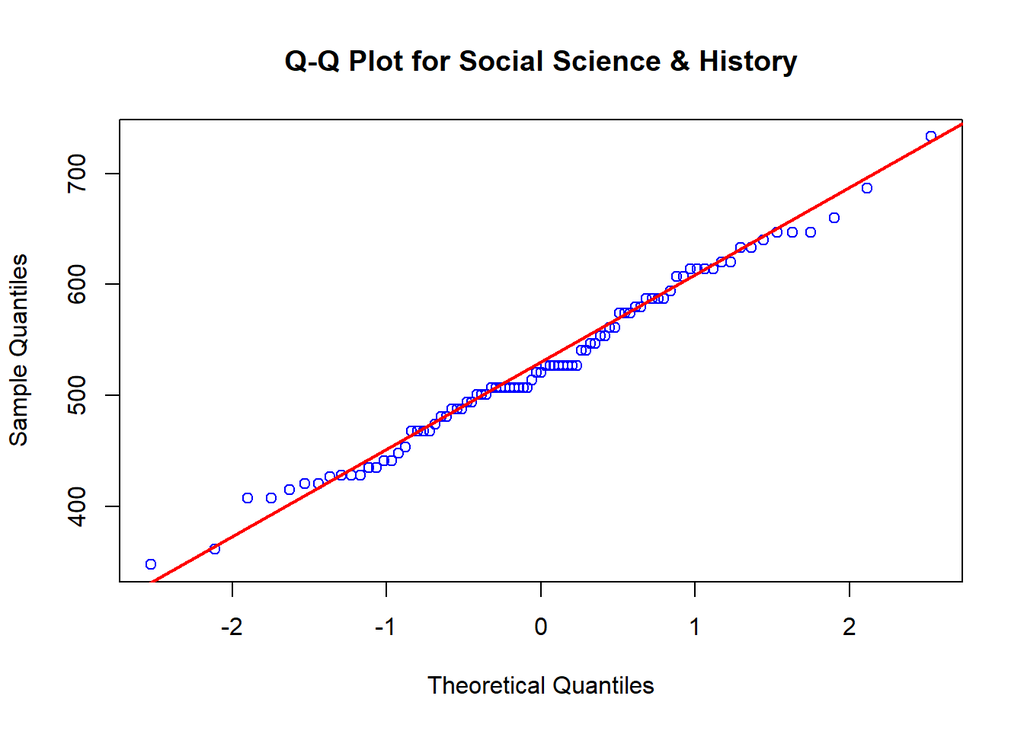

```r
library(ggplot2)
# Function to create a Q-Q plot for a given column
plot_qq <- function(column_data, column_name) {
  qq <- qqnorm(column_data, main = paste("Q-Q Plot for", column_name), col = "blue", pch = 1)
  qqline(column_data, col = "red", lwd = 2)
}

# Create Q-Q plots for each subject
plot_qq(data1$score1, "Social Science & History")
```

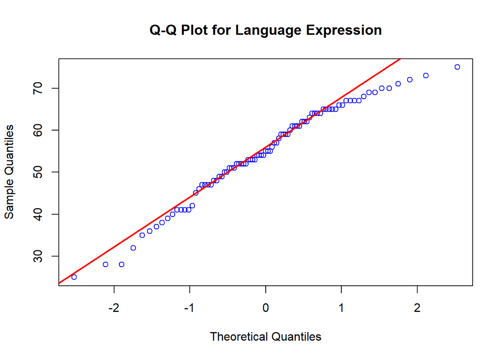

```r
plot_qq(data1$score2, "Language Expression")
```

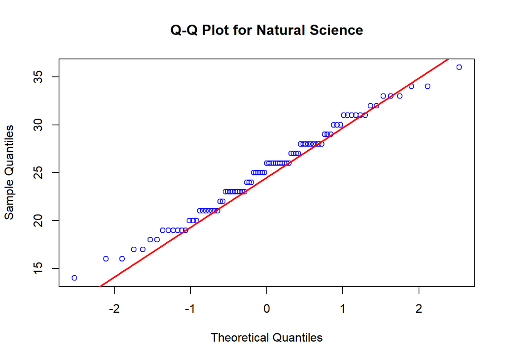

```r
plot_qq(data1$score3, "Natural Science")
```

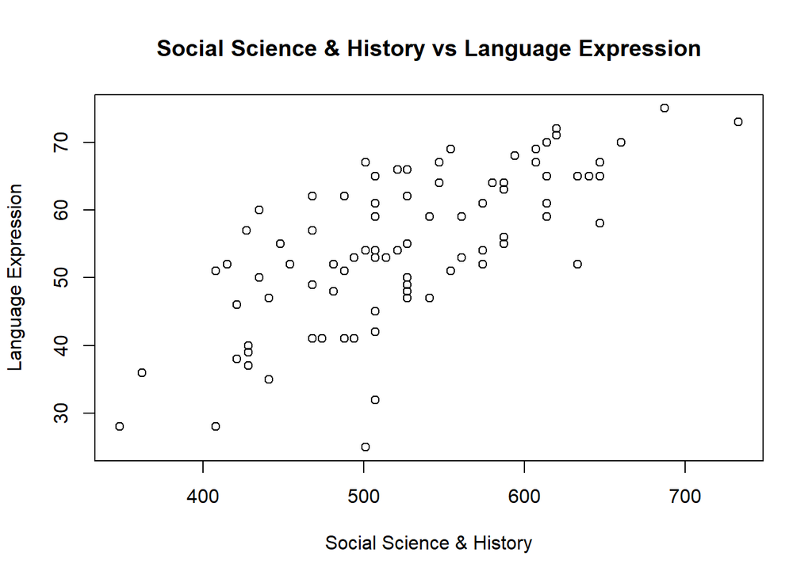

```r
# Create scatter plot for Social Science & History vs Language Expression
plot(data1$score1, data1$score2,
     xlab = "Social Science & History",
     ylab = "Language Expression",
     main = "Social Science & History vs Language Expression")
```

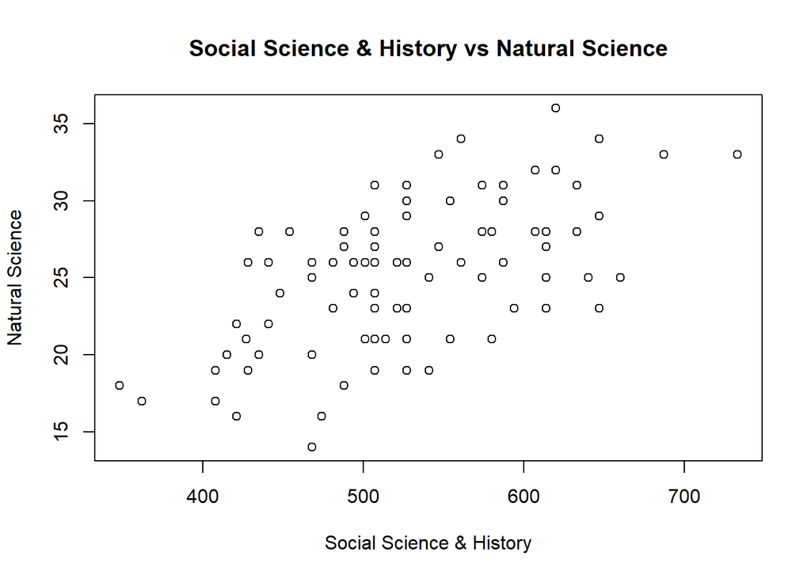

```r
# Create scatter plot for Social Science & History vs Natural Science
plot(data1$score1, data1$score3,
     xlab = "Social Science & History",
     ylab = "Natural Science",
     main = "Social Science & History vs Natural Science")
```

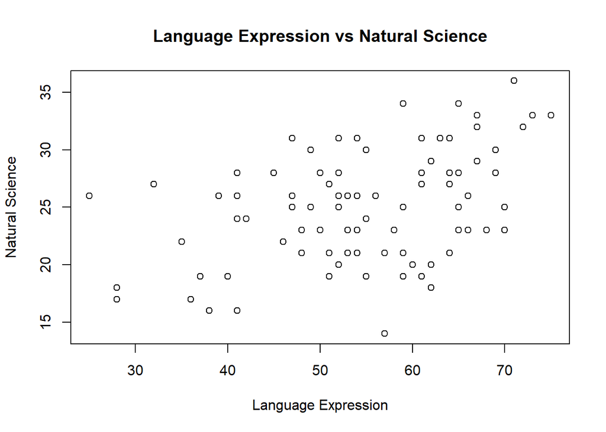

```r
# Create scatter plot for Language Expression vs Natural Science
plot(data1$score2, data1$score3,
     xlab = "Language Expression",
     ylab = "Natural Science",
     main = "Language Expression vs Natural Science")
```

From the above plots, we can draw a initial conclusion: Social Science & History has a large probability to be from a Normal dist. Language Expression may not from a Normal dist. as the tails deviate from the line too much. Natural Science’s data points all have a tendency to be more left, it’s hard to from a Normal dist.

Below is the extra bonferroni method:

```r
n <- nrow(data1) # Sample size
alpha <- 0.05 # Significance level for 95% confidence
m <- 3 # Number of comparisons/tests

# Adjusted alpha for Bonferroni correction
adjusted_alpha <- alpha / m

# Find critical z-value for the adjusted confidence level(two-sided)
z <- qnorm(1 - adjusted_alpha / 2)

# Calculate means and standard errors
means <- colMeans(data1)
sds <- apply(data1, 2, sd) #第二个参数 2 指定了 apply() 函数沿着列的方向进行操作，即对数据框的每一列应用指定的函数。
SEs <- sds / sqrt(n)

# Construct 95% Bonferroni confidence intervals
lower_bounds <- means - z * SEs
upper_bounds <- means + z * SEs

# Print the results (一列一列的定义)
data.frame(Variable = names(means), Lower_Bound = lower_bounds, Upper_Bound = upper_bounds)
```

```
##        Variable Lower_Bound Upper_Bound
## score1   score1   507.02587   546.14655
## score2   score2    51.80802    57.57129
## score3   score3    23.89254    26.36033
```

Question 6.16: Only do the hypothesis testing

```r
data2 <- read.csv("C:/Users/Synlim/Desktop/hw_data/T4-3.csv",header = F)
colnames(data2) <- c("x1", "x2", "x3", "x4","d2")
head(data2)
```

```
##     x1   x2   x3   x4   d2
## 1 1889 1651 1561 1778 0.60
## 2 2403 2048 2087 2197 5.48
## 3 2119 1700 1815 2222 7.62
## 4 1645 1627 1110 1533 5.21
## 5 1976 1916 1614 1883 1.40
## 6 1712 1712 1439 1546 2.22
```

We consider to combine the dynamic and the static cases when analyzing: we test
$$H_0:C\mu = 0$$

```r
means <- colMeans(data2[,1:4])
print(means)
```

```
##       x1       x2       x3       x4
## 1906.100 1749.533 1509.133 1724.967
```

```r
#mu <- c((means[1]+means[2])/2, (means[3]+means[4])/2)
#print(mu)
contrast_matrix <- matrix(c(-1, 0, 1, 0, 0, -1, 1, 0, -1, 0, 0, 1), nrow = 3, byrow = TRUE)
print(contrast_matrix)
```

```
##      [,1] [,2] [,3] [,4]
## [1,]   -1    0    1    0
## [2,]    0   -1    1    0
## [3,]   -1    0    0    1
```

```r
C <- contrast_matrix
q <- 4
n <- nrow(data2)
Sn <- cov(data2[,1:4])
S <- Sn*n/(n-1)
print(S)
```

```
##           x1        x2       x3        x4
## x1 109258.24  97876.07 90299.70  97480.06
## x2  97876.07 105010.47 78762.52  83859.69
## x3  90299.70  78762.52 95086.64  93467.98
## x4  97480.06  83859.69 93467.98 107822.03
```

```r
print(Sn)
```

```
##           x1        x2       x3        x4
## x1 105616.30  94613.53 87289.71  94230.73
## x2  94613.53 101510.12 76137.10  81064.36
## x3  87289.71  76137.10 91917.09  90352.38
## x4  94230.73  81064.36 90352.38 104227.96
```

```r
#print(n)
Xbar <- matrix(means, ncol = 1)
T2 <- n * t((C %*% Xbar)) %*% (solve(C%*%S%*%t(C))) %*% (C%*%Xbar)
print(T2)
```

```
##          [,1]
## [1,] 246.2305
```

```r
F_critical <- qf(0.95, df1 = q-1, df2 = n-q+1)
print(F_critical)
```

```
## [1] 2.960351
```

```r
# Calculate the critical value of T-squared
T2_critical <- ((n - 1) * (q-1) * F_critical) / (n - q + 1)
print(T2_critical)
```

```
## [1] 9.53891
```

As T2 > T2_critical, we can reject the null hypothesis, which means there is a difference between the two kinds of measurements.

Question 6.25: construction of MANOVA Table

```r
data3 <- read.csv("C:/Users/Synlim/Desktop/hw_data/T11-7.csv",header = F)
colnames(data3) <- c("x1", "x2", "x3", "x4", "x5", "Area")
head(data3)
```

```
##    x1 x2   x3   x4    x5    Area
## 1 3.9 51 0.20 7.06 12.19 Wilhelm
## 2 2.7 49 0.07 7.14 12.23 Wilhelm
## 3 2.8 36 0.30 7.00 11.30 Wilhelm
## 4 3.1 45 0.08 7.20 13.01 Wilhelm
## 5 3.5 46 0.10 7.81 12.63 Wilhelm
## 6 3.9 43 0.07 6.25 10.42 Wilhelm
```

```r
g <- 3
p <- ncol(data3) - 1
table(data3$Area)
```

```
##
## SubMuli   Upper Wilhelm
##      11      38       7
```

```r
grouped_data <- split(data3, data3$Area)
print(grouped_data)
```

```
## $SubMuli
##     x1 x2   x3   x4    x5    Area
## 8  5.0 47 0.07 7.06  6.10 SubMuli
## 9  3.4 32 0.20 5.82  4.69 SubMuli
## 10 1.2 12 0.00 5.54  3.15 SubMuli
## 11 8.4 17 0.07 6.31  4.55 SubMuli
## 12 4.2 36 0.50 9.25  4.95 SubMuli
## 13 4.2 35 0.50 5.69  2.22 SubMuli
## 14 3.9 41 0.10 5.63  2.94 SubMuli
## 15 3.9 36 0.07 6.19  2.27 SubMuli
## 16 7.3 32 0.30 8.02 12.92 SubMuli
## 17 4.4 46 0.07 7.54  5.76 SubMuli
## 18 3.0 30 0.00 5.12 10.77 SubMuli
##
## $Upper
```

[output cut: 49 more lines]

```r
library(stats)
xbar <- colMeans(data3[,1:5])
xbar1 <- colMeans(data3[1:7,1:5])
xbar2 <- colMeans(data3[8:18,1:5])
xbar3 <- colMeans(data3[19:56,1:5])
manova_result <- manova(cbind(data3$x1, data3$x2,data3$x3, data3$x4, data3$x5) ~ data3$Area, data = data3)
print(manova_result)
```

```
## Call:
##    manova(cbind(data3$x1, data3$x2, data3$x3, data3$x4, data3$x5) ~
##     data3$Area, data = data3)
##
## Terms:
##                 data3$Area Residuals
## resp 1             135.673   187.575
## resp 2            3186.681  4221.158
## resp 3               0.984     4.436
## resp 4              48.803    57.040
## resp 5             209.294   338.023
## Deg. of Freedom          2        53
##
## Residual standard errors: 1.881264 8.924376 0.2892953 1.037417 2.525429
## Estimated effects may be unbalanced
```

```r
summary(manova_result,test = "Wilks")
```

```
##            Df   Wilks approx F num Df den Df    Pr(>F)
## data3$Area  2 0.11591   18.985     10     98 < 2.2e-16 ***
## Residuals  53
## ---
## Signif. codes:  0 '***' 0.001 '**' 0.01 '*' 0.05 '.' 0.1 ' ' 1
```

We can see the p-value < 0.05, as a result, the treatments among the 3 areas are significantly different!

Question 8.12:

```r
data <- read.csv("C:/Users/Synlim/Desktop/hw_data/T1-5.csv",header = F)
colnames(data) <- c("x1", "x2", "x3", "x4", "x5", "x6","x7")
head(data)
```

```
##   x1  x2 x3 x4 x5 x6 x7
## 1  8  98  7  2 12  8  2
## 2  7 107  4  3  9  5  3
## 3  7 103  4  3  5  6  3
## 4 10  88  5  2  8 15  4
## 5  6  91  4  2  8 10  3
## 6  8  90  5  2 12 12  4
```

```r
# 使用协方差矩阵进行PCA
pca_cov <- prcomp(data, scale. = FALSE)  # scale. = FALSE意味着不先对数据进行标准化

# 使用相关系数矩阵进行PCA
pca_cor <- prcomp(data, scale. = TRUE)   # scale. = TRUE会先对数据进行标准化

# 查看PCA结果
summary(pca_cov)
```

```
## Importance of components:
##                           PC1     PC2     PC3     PC4     PC5     PC6    PC7
## Standard deviation     17.443 5.31753 3.38592 1.58881 1.13116 0.72714 0.4578
## Proportion of Variance  0.873 0.08113 0.03289 0.00724 0.00367 0.00152 0.0006
## Cumulative Proportion   0.873 0.95408 0.98697 0.99421 0.99788 0.99940 1.0000
```

```r
summary(pca_cor)
```

```
## Importance of components:
##                           PC1    PC2    PC3    PC4     PC5     PC6     PC7
## Standard deviation     1.5287 1.1773 1.0973 0.8527 0.80838 0.73259 0.39484
## Proportion of Variance 0.3338 0.1980 0.1720 0.1039 0.09335 0.07667 0.02227
## Cumulative Proportion  0.3338 0.5318 0.7038 0.8077 0.90106 0.97773 1.00000
```

```r
# 查看各主成分的贡献
pca_cov$sdev^2
```

```
## [1] 304.2578640  28.2761046  11.4644830   2.5243296   1.2795247   0.5287288
## [7]   0.2096157
```

```r
pca_cor$sdev^2
```

```
## [1] 2.3367826 1.3860007 1.2040659 0.7270865 0.6534765 0.5366888 0.1558989
```

```r
# 查看由prcomp得到的主成分的载荷
pca_cov$rotation
```

```
##             PC1         PC2         PC3           PC4           PC5
## x1 -0.010039244  0.07622439 -0.03087761  0.9203045748  0.3423859285
## x2  0.993199405  0.11615518 -0.00659069 -0.0002118679  0.0022391022
## x3  0.014062314 -0.09956775  0.18282641 -0.1382922410  0.6500776063
## x4 -0.004710175  0.01320423  0.13021553 -0.3277842624  0.6431560485
## x5  0.024255644 -0.15038113  0.95526318  0.1023719020 -0.2065840405
## x6  0.112429558 -0.97335904 -0.16981025  0.0632480276 -0.0002935726
## x7  0.002340785 -0.02382046  0.08519558  0.1095073458  0.0619613872
##             PC6          PC7
## x1 -0.011779079 -0.169729925
## x2 -0.003353218 -0.001781987
## x3  0.563893916  0.443577538
## x4 -0.497513370 -0.462855916
## x5  0.009009299 -0.105029951
## x6 -0.051067254 -0.066992404
## x7 -0.657012233  0.738019426
```

```r
pca_cor$rotation
```

```
##           PC1          PC2        PC3          PC4         PC5          PC6
## x1 -0.2368211  0.278445138 -0.6434744  0.172719491 -0.56053441  0.223579220
## x2  0.2055665 -0.526613869 -0.2244690  0.778136601  0.15613432  0.005700851
## x3  0.5510839 -0.006819502  0.1136089  0.005301798 -0.57342221  0.109538907
## x4  0.3776151  0.434674253  0.4070978  0.290503052  0.05669070  0.450234781
## x5  0.4980161  0.199767367 -0.1965567 -0.042428178 -0.05021430 -0.744968707
## x6  0.3245506 -0.566973655 -0.1598465 -0.507915905 -0.08024349  0.330583071
## x7  0.3194032  0.307882771 -0.5410484 -0.143082348  0.56607057  0.266469812
##            PC7
## x1  0.24146701
## x2  0.01126548
## x3 -0.58524622
## x4  0.46088973
## x5  0.33784371
## x6  0.41707805
## x7 -0.31391372
```

```r
# 计算协方差矩阵
cov_matrix <- cov(data)

# 计算相关系数矩阵
cor_matrix <- cor(data)
print(cov_matrix)
```

```
##            x1          x2         x3         x4         x5         x6        x7
## x1  2.5000000  -2.7804878 -0.3780488 -0.4634146 -0.5853659 -2.2317073 0.1707317
## x2 -2.7804878 300.5156794  3.9094077 -1.3867596  6.7630662 30.7909408 0.6236934
## x3 -0.3780488   3.9094077  1.5220674  0.6736353  2.3147503  2.8217189 0.1416957
## x4 -0.4634146  -1.3867596  0.6736353  1.1823461  1.0882695 -0.8106852 0.1765389
## x5 -0.5853659   6.7630662  2.3147503  1.0882695 11.3635308  3.1265970 1.0441347
## x6 -2.2317073  30.7909408  2.8217189 -0.8106852  3.1265970 30.9785134 0.5946574
## x7  0.1707317   0.6236934  0.1416957  0.1765389  1.0441347  0.5946574 0.4785134
```

```r
print(cor_matrix)
```

```
##            x1          x2         x3          x4         x5         x6
## x1  1.0000000 -0.10144191 -0.1938032 -0.26954261 -0.1098249 -0.2535928
## x2 -0.1014419  1.00000000  0.1827934 -0.07356907  0.1157320  0.3191237
## x3 -0.1938032  0.18279338  1.0000000  0.50215246  0.5565838  0.4109288
## x4 -0.2695426 -0.07356907  0.5021525  1.00000000  0.2968981 -0.1339521
## x5 -0.1098249  0.11573199  0.5565838  0.29689814  1.0000000  0.1666422
## x6 -0.2535928  0.31912373  0.4109288 -0.13395214  0.1666422  1.0000000
## x7  0.1560979  0.05201044  0.1660323  0.23470432  0.4477678  0.1544506
##            x7
## x1 0.15609793
## x2 0.05201044
## x3 0.16603235
## x4 0.23470432
## x5 0.44776780
## x6 0.15445056
## x7 1.00000000
```

```r
eigen(cov_matrix)$values
```

```
## [1] 304.2578640  28.2761046  11.4644830   2.5243296   1.2795247   0.5287288
## [7]   0.2096157
```

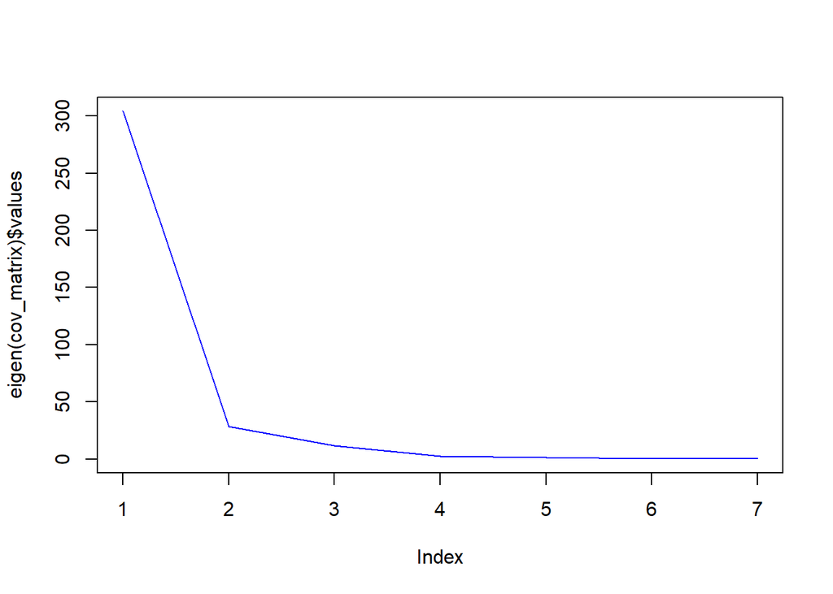

```r
plot(eigen(cov_matrix)$values, type = 'l',col = 'blue')
```

```r
eigen(cor_matrix)$values
```

```
## [1] 2.3367826 1.3860007 1.2040659 0.7270865 0.6534765 0.5366888 0.1558989
```

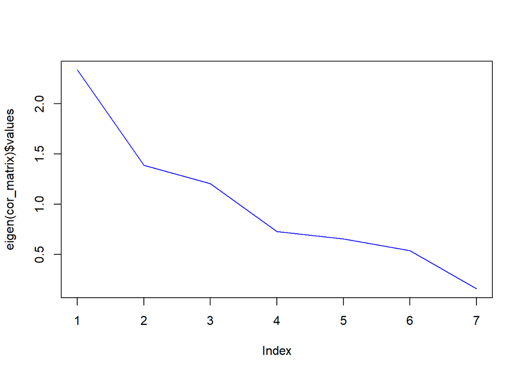

```r
plot(eigen(cor_matrix)$values, type = 'l',col = 'blue')
```

Using the covariance matrix: Yes, the first three principal components of pca_cov explain approximately 98.69% of the variance, which is very high. It’s even okay to use less than 3 components.

Using the correlation matrix: With only 70.38% of the variance explained by the first three components in pca_cor, it may be less clear. While 70% represents a significant portion of the variance, depending on the context and purpose of the analysis, it might not be enough to capture all the nuances of the data. More components might be needed to have a comprehensive understanding.

Here, if we want to see every indicator equally important, then the cor method should be used and vice versa.

Question 9.20:

```r
Sn <- cov(data)
print(Sn)
```

```
##            x1          x2         x3         x4         x5         x6        x7
## x1  2.5000000  -2.7804878 -0.3780488 -0.4634146 -0.5853659 -2.2317073 0.1707317
## x2 -2.7804878 300.5156794  3.9094077 -1.3867596  6.7630662 30.7909408 0.6236934
## x3 -0.3780488   3.9094077  1.5220674  0.6736353  2.3147503  2.8217189 0.1416957
## x4 -0.4634146  -1.3867596  0.6736353  1.1823461  1.0882695 -0.8106852 0.1765389
## x5 -0.5853659   6.7630662  2.3147503  1.0882695 11.3635308  3.1265970 1.0441347
## x6 -2.2317073  30.7909408  2.8217189 -0.8106852  3.1265970 30.9785134 0.5946574
## x7  0.1707317   0.6236934  0.1416957  0.1765389  1.0441347  0.5946574 0.4785134
```

```r
n <- nrow(data)
S <- n*Sn/(n-1)
print(S)
```

```
##            x1          x2         x3         x4         x5         x6        x7
## x1  2.5609756  -2.8483046 -0.3872695 -0.4747174 -0.5996431 -2.2861392 0.1748959
## x2 -2.8483046 307.8453302  4.0047591 -1.4205830  6.9280190 31.5419393 0.6389054
## x3 -0.3872695   4.0047591  1.5591910  0.6900654  2.3712076  2.8905413 0.1451517
## x4 -0.4747174  -1.4205830  0.6900654  1.2111838  1.1148126 -0.8304581 0.1808447
## x5 -0.5996431   6.9280190  2.3712076  1.1148126 11.6406901  3.2028554 1.0696014
## x6 -2.2861392  31.5419393  2.8905413 -0.8304581  3.2028554 31.7340869 0.6091612
## x7  0.1748959   0.6389054  0.1451517  0.1808447  1.0696014  0.6091612 0.4901844
```

```r
library(psych)
# (a) Conduct PCA with one and two common factors
mu <- colMeans(data)
print(mu)
```

```
##        x1        x2        x3        x4        x5        x6        x7
##  7.500000 73.857143  4.547619  2.190476 10.047619  9.404762  3.095238
```

```r
ei_result <- eigen(S)
print(ei_result$values)
```

```
## [1] 311.6787876  28.9657657  11.7441045   2.5858986   1.3107326   0.5416246
## [7]   0.2147283
```

```r
print(ei_result$vectors)
```

```
##              [,1]        [,2]        [,3]          [,4]          [,5]
## [1,]  0.010039244  0.07622439  0.03087761  0.9203045748  0.3423859285
## [2,] -0.993199405  0.11615518  0.00659069 -0.0002118679  0.0022391022
## [3,] -0.014062314 -0.09956775 -0.18282641 -0.1382922410  0.6500776063
## [4,]  0.004710175  0.01320423 -0.13021553 -0.3277842624  0.6431560485
## [5,] -0.024255644 -0.15038113 -0.95526318  0.1023719020 -0.2065840405
## [6,] -0.112429558 -0.97335904  0.16981025  0.0632480276 -0.0002935726
## [7,] -0.002340785 -0.02382046 -0.08519558  0.1095073458  0.0619613872
##              [,6]         [,7]
## [1,]  0.011779079 -0.169729925
## [2,]  0.003353218 -0.001781987
## [3,] -0.563893916  0.443577538
## [4,]  0.497513370 -0.462855916
## [5,] -0.009009299 -0.105029951
## [6,]  0.051067254 -0.066992404
## [7,]  0.657012233  0.738019426
```

```r
#when m = 1
L1 <- sqrt(ei_result$values[1])*ei_result$vectors[,1]
print(L1)
```

```
## [1]   0.17723711 -17.53436625  -0.24826209   0.08315544  -0.42821950
## [6]  -1.98487941  -0.04132522
```

```r
diag_phi1 <- diag(S - (L1)%*%t(L1))
phi1 <- diag(diag_phi1)
print(phi1)
```

```
##          [,1]      [,2]     [,3]     [,4]     [,5]     [,6]      [,7]
## [1,] 2.529563 0.0000000 0.000000 0.000000  0.00000  0.00000 0.0000000
## [2,] 0.000000 0.3913305 0.000000 0.000000  0.00000  0.00000 0.0000000
## [3,] 0.000000 0.0000000 1.497557 0.000000  0.00000  0.00000 0.0000000
## [4,] 0.000000 0.0000000 0.000000 1.204269  0.00000  0.00000 0.0000000
## [5,] 0.000000 0.0000000 0.000000 0.000000 11.45732  0.00000 0.0000000
## [6,] 0.000000 0.0000000 0.000000 0.000000  0.00000 27.79434 0.0000000
## [7,] 0.000000 0.0000000 0.000000 0.000000  0.00000  0.00000 0.4884766
```

```r
print(L1%*%t(L1)+phi1)
```

```
##              [,1]        [,2]        [,3]         [,4]        [,5]        [,6]
## [1,]  2.560975610  -3.1077403 -0.04400125  0.014738229 -0.07589638 -0.35179428
## [2,] -3.107740339 307.8453302  4.35311845 -1.458077867  7.50855753 34.80360255
## [3,] -0.044001255   4.3531185  1.55919096 -0.020644342  0.10631067  0.49277032
## [4,]  0.014738229  -1.4580779 -0.02064434  1.211183819 -0.03560878 -0.16505351
## [5,] -0.075896385   7.5085575  0.10631067 -0.035608779 11.64069007  0.84996407
## [6,] -0.351794284  34.8036026  0.49277032 -0.165053512  0.84996407 31.73408685
## [7,] -0.007324362   0.7246115  0.01025948 -0.003436416  0.01769626  0.08202557
##              [,7]
## [1,] -0.007324362
## [2,]  0.724611496
## [3,]  0.010259485
## [4,] -0.003436416
## [5,]  0.017696264
## [6,]  0.082025573
## [7,]  0.490184414
```

```r
#when m = 2
L2 <- cbind(sqrt(ei_result$values[1])*ei_result$vectors[,1], sqrt(ei_result$values[2])*ei_result$vectors[,2])
print(L2)
```

```
##              [,1]        [,2]
## [1,]   0.17723711  0.41023856
## [2,] -17.53436625  0.62514549
## [3,]  -0.24826209 -0.53587219
## [4,]   0.08315544  0.07106497
## [5,]  -0.42821950 -0.80934901
## [6,]  -1.98487941 -5.23860406
## [7,]  -0.04132522 -0.12820137
```

```r
diag_phi2 <- diag(S - (L2)%*%t(L2))
phi2 <- diag(diag_phi2)
print(phi2)
```

```
##          [,1]         [,2]     [,3]     [,4]     [,5]      [,6]      [,7]
## [1,] 2.361267 0.0000000000 0.000000 0.000000  0.00000 0.0000000 0.0000000
## [2,] 0.000000 0.0005235905 0.000000 0.000000  0.00000 0.0000000 0.0000000
## [3,] 0.000000 0.0000000000 1.210398 0.000000  0.00000 0.0000000 0.0000000
## [4,] 0.000000 0.0000000000 0.000000 1.199219  0.00000 0.0000000 0.0000000
## [5,] 0.000000 0.0000000000 0.000000 0.000000 10.80227 0.0000000 0.0000000
## [6,] 0.000000 0.0000000000 0.000000 0.000000  0.00000 0.3513681 0.0000000
## [7,] 0.000000 0.0000000000 0.000000 0.000000  0.00000 0.0000000 0.4720411
```

```r
#Method of MLE
V <- sqrt(diag(diag(S)))
print(V)
```

```
##          [,1]     [,2]     [,3]     [,4]     [,5]     [,6]      [,7]
## [1,] 1.600305  0.00000 0.000000 0.000000 0.000000 0.000000 0.0000000
## [2,] 0.000000 17.54552 0.000000 0.000000 0.000000 0.000000 0.0000000
## [3,] 0.000000  0.00000 1.248676 0.000000 0.000000 0.000000 0.0000000
## [4,] 0.000000  0.00000 0.000000 1.100538 0.000000 0.000000 0.0000000
## [5,] 0.000000  0.00000 0.000000 0.000000 3.411846 0.000000 0.0000000
## [6,] 0.000000  0.00000 0.000000 0.000000 0.000000 5.633302 0.0000000
## [7,] 0.000000  0.00000 0.000000 0.000000 0.000000 0.000000 0.7001317
```

```r
# Conduct factor analysis using MLE with one factor
fa_one <- factanal(data, factors = 1, rotation = "none")

# Conduct factor analysis using MLE with two factors
fa_two <- factanal(data, factors = 2, rotation = "none")

# Print the results
print(fa_one)
```

```
##
## Call:
## factanal(x = data, factors = 1, rotation = "none")
##
## Uniquenesses:
##    x1    x2    x3    x4    x5    x6    x7
## 0.962 0.966 0.005 0.747 0.688 0.831 0.972
##
## Loadings:
##    Factor1
## x1 -0.195
## x2  0.183
## x3  0.997
## x4  0.503
## x5  0.558
## x6  0.411
## x7  0.168
##
##                Factor1
## SS loadings      1.828
## Proportion Var   0.261
##
## Test of the hypothesis that 1 factor is sufficient.
## The chi square statistic is 34.11 on 14 degrees of freedom.
## The p-value is 0.00199
```

```r
print(fa_two)
```

```
##
## Call:
## factanal(x = data, factors = 2, rotation = "none")
##
## Uniquenesses:
##    x1    x2    x3    x4    x5    x6    x7
## 0.907 0.895 0.213 0.498 0.614 0.005 0.915
##
## Loadings:
##    Factor1 Factor2
## x1 -0.168  -0.255
## x2          0.321
## x3  0.783   0.418
## x4  0.697  -0.128
## x5  0.597   0.173
## x6          0.997
## x7  0.246   0.156
##
##                Factor1 Factor2
## SS loadings      1.544   1.408
## Proportion Var   0.221   0.201
## Cumulative Var   0.221   0.422
##
## Test of the hypothesis that 2 factors are sufficient.
## The chi square statistic is 20.21 on 8 degrees of freedom.
## The p-value is 0.00956
```

```r
loading1 <- V%*%fa_one$loadings
print(loading1)
```

```
##         Factor1
## [1,] -0.3123817
## [2,]  3.2184950
## [3,]  1.2455505
## [4,]  0.5533278
## [5,]  1.9044953
## [6,]  2.3154882
## [7,]  0.1179279
```

```r
phi1mle <- V%*%diag(fa_one$uniquenesses)%*%V
print(phi1mle)
```

```
##          [,1]     [,2]        [,3]      [,4]     [,5]     [,6]      [,7]
## [1,] 2.463392   0.0000 0.000000000 0.0000000 0.000000  0.00000 0.0000000
## [2,] 0.000000 297.4864 0.000000000 0.0000000 0.000000  0.00000 0.0000000
## [3,] 0.000000   0.0000 0.007795955 0.0000000 0.000000  0.00000 0.0000000
## [4,] 0.000000   0.0000 0.000000000 0.9050112 0.000000  0.00000 0.0000000
## [5,] 0.000000   0.0000 0.000000000 0.0000000 8.013593  0.00000 0.0000000
## [6,] 0.000000   0.0000 0.000000000 0.0000000 0.000000 26.37262 0.0000000
## [7,] 0.000000   0.0000 0.000000000 0.0000000 0.000000  0.00000 0.4762773
```

```r
print(loading1%*%t(loading1)+phi1mle)
```

```
##             [,1]        [,2]       [,3]       [,4]       [,5]       [,6]
## [1,]  2.56097455  -1.0053989 -0.3890872 -0.1728495 -0.5949295 -0.7233161
## [2,] -1.00539890 307.8451223  4.0087981  1.7808826  6.1296087  7.4523871
## [3,] -0.38908717   4.0087981  1.5591920  0.6891977  2.3721451  2.8840575
## [4,] -0.17284946   1.7808826  0.6891977  1.2111828  1.0538101  1.2812239
## [5,] -0.59492946   6.1296087  2.3721451  1.0538101 11.6406956  4.4098364
## [6,] -0.72331610   7.4523871  2.8840575  1.2812239  4.4098364 31.7341041
## [7,] -0.03683853   0.3795505  0.1468852  0.0652528  0.2245932  0.2730608
##             [,7]
## [1,] -0.03683853
## [2,]  0.37955050
## [3,]  0.14688521
## [4,]  0.06525280
## [5,]  0.22459322
## [6,]  0.27306076
## [7,]  0.49018432
```

```r
loading2 <- V%*%fa_two$loadings
print(loading2)
```

```
##          Factor1    Factor2
## [1,] -0.26824671 -0.4076127
## [2,]  0.76410284  5.6246856
## [3,]  0.97715853  0.5223063
## [4,]  0.76656151 -0.1412974
## [5,]  2.03519895  0.5885625
## [6,] -0.04608299  5.6190176
## [7,]  0.17214605  0.1091387
```

```r
phi2mle <- V%*%diag(fa_two$uniquenesses)%*%V
print(phi2mle)
```

```
##          [,1]     [,2]     [,3]      [,4]     [,5]      [,6]      [,7]
## [1,] 2.322862   0.0000 0.000000 0.0000000 0.000000 0.0000000 0.0000000
## [2,] 0.000000 275.6245 0.000000 0.0000000 0.000000 0.0000000 0.0000000
## [3,] 0.000000   0.0000 0.331549 0.0000000 0.000000 0.0000000 0.0000000
## [4,] 0.000000   0.0000 0.000000 0.6036012 0.000000 0.0000000 0.0000000
## [5,] 0.000000   0.0000 0.000000 0.0000000 7.152238 0.0000000 0.0000000
## [6,] 0.000000   0.0000 0.000000 0.0000000 0.000000 0.1586704 0.0000000
## [7,] 0.000000   0.0000 0.000000 0.0000000 0.000000 0.0000000 0.4486397
```

```r
print(loading2%*%t(loading2)+phi2mle)
```

```
##             [,1]        [,2]       [,3]       [,4]       [,5]       [,6]
## [1,]  2.56096664  -2.4976614 -0.4750182 -0.1480330 -0.7858410 -2.2780214
## [2,] -2.49766145 307.8454116  3.6844580 -0.2090218  4.8655801 31.5699951
## [3,] -0.47501823   3.6844580  1.5591916  0.6752516  2.2961219  2.8898176
## [4,] -0.14803297  -0.2090218  0.6752516  1.2111828  1.4769428 -0.8292782
## [5,] -0.78584097   4.8655801  2.2961219  1.4769428 11.6406790  3.2133548
## [6,] -2.27802143  31.5699951  2.8898176 -0.8292782  3.2133548 31.7341529
## [7,] -0.09066393   0.7454081  0.2252178  0.1165395  0.4145864  0.6053192
##             [,7]
## [1,] -0.09066393
## [2,]  0.74540809
## [3,]  0.22521780
## [4,]  0.11653952
## [5,]  0.41458640
## [6,]  0.60531920
## [7,]  0.49018521
```

The loadings and uniqueness got from 2 methods are significantly different!

Question 9.21:

```r
#PCA method
V <- sqrt(diag(diag(S)))
pca_two <- principal(data, nfactors = 2, rotate = "varimax")

# (b) Calculate the loading matrix for each case
loadings_two <- V %*% pca_two$loadings

# (c) Derive the communalities for the original variables
uniqueness_two <- V %*% diag(pca_two$uniquenesses) %*% V
print(loadings_two)
```

```
##             RC1         RC2
## [1,] -0.1977921 -0.75611574
## [2,] -1.3384176 12.12161301
## [3,]  0.8749169  0.58405914
## [4,]  0.8399124 -0.12369944
## [5,]  2.6130659  0.74988628
## [6,]  0.2813567  4.67661969
## [7,]  0.4249911 -0.02532014
```

```r
print(uniqueness_two)
```

```
##          [,1]     [,2]      [,3]      [,4]     [,5]     [,6]      [,7]
## [1,] 1.950143   0.0000 0.0000000 0.0000000 0.000000 0.000000 0.0000000
## [2,] 0.000000 159.1205 0.0000000 0.0000000 0.000000 0.000000 0.0000000
## [3,] 0.000000   0.0000 0.4525863 0.0000000 0.000000 0.000000 0.0000000
## [4,] 0.000000   0.0000 0.0000000 0.4904295 0.000000 0.000000 0.0000000
## [5,] 0.000000   0.0000 0.0000000 0.0000000 4.250247 0.000000 0.0000000
## [6,] 0.000000   0.0000 0.0000000 0.0000000 0.000000 9.784154 0.0000000
## [7,] 0.000000   0.0000 0.0000000 0.0000000 0.000000 0.000000 0.3089259
```

```r
print(loadings_two%*%t(loadings_two)+uniqueness_two)
```

```
##             [,1]        [,2]       [,3]        [,4]      [,5]         [,6]
## [1,]  2.56097561  -8.9006140 -0.6146680 -0.07259693 -1.083845 -3.591715895
## [2,] -8.90061399 307.8453302  5.9087347 -2.62359024  5.592458 56.311601425
## [3,] -0.61466796   5.9087347  1.5591910  0.66260574  2.724194  2.977586183
## [4,] -0.07259693  -2.6235902  0.6626057  1.21118382  2.101986 -0.342180296
## [5,] -1.08384461   5.5924578  2.7241935  2.10198584 11.640690  4.242136464
## [6,] -3.59171589  56.3116014  2.9775862 -0.34218030  4.242136 31.734086853
## [7,] -0.06491493  -0.8757365  0.3570435  0.36008738  1.091543  0.001161427
##              [,7]
## [1,] -0.064914929
## [2,] -0.875736521
## [3,]  0.357043459
## [4,]  0.360087379
## [5,]  1.091542584
## [6,]  0.001161427
## [7,]  0.490184414
```

```r
#MLE method
# Conduct factor analysis using MLE with two factors
fa_two <- factanal(data, factors = 2, rotation = "varimax")

# Print the results
print(fa_two)
```

```
##
## Call:
## factanal(x = data, factors = 2, rotation = "varimax")
##
## Uniquenesses:
##    x1    x2    x3    x4    x5    x6    x7
## 0.907 0.895 0.213 0.498 0.614 0.005 0.915
##
## Loadings:
##    Factor1 Factor2
## x1 -0.176  -0.249
## x2          0.319
## x3  0.797   0.391
## x4  0.692  -0.152
## x5  0.602   0.152
## x6          0.997
## x7  0.251   0.147
##
##                Factor1 Factor2
## SS loadings      1.573   1.379
## Proportion Var   0.225   0.197
## Cumulative Var   0.225   0.422
##
## Test of the hypothesis that 2 factors are sufficient.
## The chi square statistic is 20.21 on 8 degrees of freedom.
## The p-value is 0.00956
```

```r
loading2 <- V%*%fa_two$loadings
print(loading2)
```

```
##         Factor1    Factor2
## [1,] -0.2821644 -0.3981051
## [2,]  0.9579063  5.5949402
## [3,]  0.9946144  0.4882466
## [4,]  0.7612242 -0.1676878
## [5,]  2.0543119  0.5179218
## [6,]  0.1480081  5.6172570
## [7,]  0.1758127  0.1031282
```

```r
phi2mle <- V%*%diag(fa_two$uniquenesses)%*%V
print(phi2mle)
```

```
##          [,1]     [,2]     [,3]      [,4]     [,5]      [,6]      [,7]
## [1,] 2.322862   0.0000 0.000000 0.0000000 0.000000 0.0000000 0.0000000
## [2,] 0.000000 275.6245 0.000000 0.0000000 0.000000 0.0000000 0.0000000
## [3,] 0.000000   0.0000 0.331549 0.0000000 0.000000 0.0000000 0.0000000
## [4,] 0.000000   0.0000 0.000000 0.6036012 0.000000 0.0000000 0.0000000
## [5,] 0.000000   0.0000 0.000000 0.0000000 7.152238 0.0000000 0.0000000
## [6,] 0.000000   0.0000 0.000000 0.0000000 0.000000 0.1586704 0.0000000
## [7,] 0.000000   0.0000 0.000000 0.0000000 0.000000 0.0000000 0.4486397
```

```r
print(loading2%*%t(loading2)+phi2mle)
```

```
##             [,1]        [,2]       [,3]       [,4]       [,5]       [,6]
## [1,]  2.56096664  -2.4976614 -0.4750182 -0.1480330 -0.7858410 -2.2780214
## [2,] -2.49766145 307.8454116  3.6844580 -0.2090218  4.8655801 31.5699951
## [3,] -0.47501823   3.6844580  1.5591916  0.6752516  2.2961219  2.8898176
## [4,] -0.14803297  -0.2090218  0.6752516  1.2111828  1.4769428 -0.8292782
## [5,] -0.78584097   4.8655801  2.2961219  1.4769428 11.6406790  3.2133548
## [6,] -2.27802143  31.5699951  2.8898176 -0.8292782  3.2133548 31.7341529
## [7,] -0.09066393   0.7454081  0.2252178  0.1165395  0.4145864  0.6053192
##             [,7]
## [1,] -0.09066393
## [2,]  0.74540809
## [3,]  0.22521780
## [4,]  0.11653952
## [5,]  0.41458640
## [6,]  0.60531920
## [7,]  0.49018521
```

```r
#difference = PCA - MLE
print(loadings_two - loading2)
```

```
##              RC1         RC2
## [1,]  0.08437227 -0.35801061
## [2,] -2.29632393  6.52667276
## [3,] -0.11969751  0.09581253
## [4,]  0.07868814  0.04398837
## [5,]  0.55875399  0.23196444
## [6,]  0.13334860 -0.94063729
## [7,]  0.24917845 -0.12844832
```

```r
print(uniqueness_two - phi2mle)
```

```
##            [,1]     [,2]      [,3]       [,4]      [,5]     [,6]       [,7]
## [1,] -0.3727193    0.000 0.0000000  0.0000000  0.000000 0.000000  0.0000000
## [2,]  0.0000000 -116.504 0.0000000  0.0000000  0.000000 0.000000  0.0000000
## [3,]  0.0000000    0.000 0.1210373  0.0000000  0.000000 0.000000  0.0000000
## [4,]  0.0000000    0.000 0.0000000 -0.1131717  0.000000 0.000000  0.0000000
## [5,]  0.0000000    0.000 0.0000000  0.0000000 -2.901991 0.000000  0.0000000
## [6,]  0.0000000    0.000 0.0000000  0.0000000  0.000000 9.625483  0.0000000
## [7,]  0.0000000    0.000 0.0000000  0.0000000  0.000000 0.000000 -0.1397138
```

We can see from the last two ‘print’, the output from PCA and MLE still varies!

Question 9.22:(a) for the MLE and m = 2 case: loading2 and phi2mle(from the varimax case)

```r
cal_mat <- solve(t(loading2) %*% solve(phi2mle) %*% loading2) %*% t(loading2) %*%solve(phi2mle)
mymeans <- colMeans(data)
# 创建一个空的数据框来存储结果
result_df <- data.frame(matrix(nrow = nrow(data), ncol = nrow(cal_mat)))

# 给结果数据框添加列名
colnames(result_df) <- paste0("Factor", 1:nrow(cal_mat))

# 循环计算结果并添加到结果数据框中
for (i in 1:nrow(data)) {
  f <- cal_mat %*% (t(data[i,]) - mymeans)
  result_df[i, ] <- as.vector(f)
}

# 输出结果数据框
print(result_df)
```

```
##        Factor1     Factor2
## 1   1.64971848 -0.28472696
## 2   0.08479111 -0.78490902
## 3  -0.22574512 -0.59915266
## 4  -0.18967333  1.00064843
## 5  -0.53013743  0.12174073
## 6   0.28598191  0.45657860
## 7   2.02312440  0.94092487
## 8   2.00571676  0.76134224
## 9  -0.06195714  0.29112717
## 10  0.50587388 -0.08449925
## 11  1.19376507 -1.17306842
## 12 -0.10655421 -0.42248863
## 13  2.56203562  0.03747239
## 14 -0.28370452 -0.42243098
```

[output cut: 28 more lines]

```r
#for the regression method
cal_mat2 <- t(loading2) %*% solve(loading2 %*% t(loading2) + phi2mle)

# 创建一个空的数据框来存储结果
result_df2 <- data.frame(matrix(nrow = nrow(data), ncol = nrow(cal_mat2)))

# 给结果数据框添加列名
colnames(result_df2) <- paste0("Factor", 1:nrow(cal_mat2))

# 循环计算结果并添加到结果数据框中
for (i in 1:nrow(data)) {
  f <- cal_mat2 %*% (t(data[i,]) - mymeans)
  result_df2[i, ] <- as.vector(f)
}

# 输出结果数据框
print(result_df2)
```

```
##        Factor1     Factor2
## 1   1.35083131 -0.27326582
## 2   0.06476663 -0.78032860
## 3  -0.18870834 -0.59741446
## 4  -0.14945055  0.99431526
## 5  -0.43390690  0.11790097
## 6   0.23723168  0.45594379
## 7   1.66439453  0.94829525
## 8   1.64903550  0.76953780
## 9  -0.04903461  0.28924361
## 10  0.41423937 -0.08099934
## 11  0.97163163 -1.15976403
## 12 -0.08991793 -0.42094438
## 13  2.10076309  0.05278625
## 14 -0.23515781 -0.42195932
```

[output cut: 28 more lines]

```r
V <- sqrt(diag(diag(S)))
pca_two <- principal(data, nfactors = 2, rotate = "varimax")

# (b) Calculate the loading matrix for each case
loadings_two <- V %*% pca_two$loadings

# (c) Derive the communalities for the original variables
uniqueness_two <- V %*% diag(pca_two$uniquenesses) %*% V
print(loadings_two)
```

```
##             RC1         RC2
## [1,] -0.1977921 -0.75611574
## [2,] -1.3384176 12.12161301
## [3,]  0.8749169  0.58405914
## [4,]  0.8399124 -0.12369944
## [5,]  2.6130659  0.74988628
## [6,]  0.2813567  4.67661969
## [7,]  0.4249911 -0.02532014
```

```r
print(uniqueness_two)
```

```
##          [,1]     [,2]      [,3]      [,4]     [,5]     [,6]      [,7]
## [1,] 1.950143   0.0000 0.0000000 0.0000000 0.000000 0.000000 0.0000000
## [2,] 0.000000 159.1205 0.0000000 0.0000000 0.000000 0.000000 0.0000000
## [3,] 0.000000   0.0000 0.4525863 0.0000000 0.000000 0.000000 0.0000000
## [4,] 0.000000   0.0000 0.0000000 0.4904295 0.000000 0.000000 0.0000000
## [5,] 0.000000   0.0000 0.0000000 0.0000000 4.250247 0.000000 0.0000000
## [6,] 0.000000   0.0000 0.0000000 0.0000000 0.000000 9.784154 0.0000000
## [7,] 0.000000   0.0000 0.0000000 0.0000000 0.000000 0.000000 0.3089259
```

```r
print(loadings_two%*%t(loadings_two)+uniqueness_two)
```

```
##             [,1]        [,2]       [,3]        [,4]      [,5]         [,6]
## [1,]  2.56097561  -8.9006140 -0.6146680 -0.07259693 -1.083845 -3.591715895
## [2,] -8.90061399 307.8453302  5.9087347 -2.62359024  5.592458 56.311601425
## [3,] -0.61466796   5.9087347  1.5591910  0.66260574  2.724194  2.977586183
## [4,] -0.07259693  -2.6235902  0.6626057  1.21118382  2.101986 -0.342180296
## [5,] -1.08384461   5.5924578  2.7241935  2.10198584 11.640690  4.242136464
## [6,] -3.59171589  56.3116014  2.9775862 -0.34218030  4.242136 31.734086853
## [7,] -0.06491493  -0.8757365  0.3570435  0.36008738  1.091543  0.001161427
##              [,7]
## [1,] -0.064914929
## [2,] -0.875736521
## [3,]  0.357043459
## [4,]  0.360087379
## [5,]  1.091542584
## [6,]  0.001161427
## [7,]  0.490184414
```

```r
cal_mat3 <- solve(t(loading2) %*% loading2) %*% t(loading2)
mymeans <- colMeans(data)
# 创建一个空的数据框来存储结果
result_df3 <- data.frame(matrix(nrow = nrow(data), ncol = nrow(cal_mat3)))

# 给结果数据框添加列名
colnames(result_df3) <- paste0("Factor", 1:nrow(cal_mat3))

# 循环计算结果并添加到结果数据框中
for (i in 1:nrow(data)) {
  f <- cal_mat3 %*% (t(data[i,]) - mymeans)
  result_df3[i, ] <- as.vector(f)
}

# 输出结果数据框
print(result_df3)
```

```
##         Factor1       Factor2
## 1   2.232275926  1.7594238006
## 2   1.637803615  2.3166991529
## 3   0.008390254  2.2188831266
## 4  -0.565258652  1.7813747853
## 5   0.002407726  1.5501632439
## 6   1.231623381  1.5185135996
## 7   1.247971407  1.2589461340
## 8   3.788472533 -0.1061387083
## 9   0.489274487  0.8155039730
## 10  0.623736786 -0.9530613661
## 11  0.801113680 -0.9075693318
## 12  1.626288959  1.1198009422
## 13  3.190764621 -0.4177410369
## 14  0.145809221 -0.5815682132
```

[output cut: 28 more lines]

Question 9.22:(c)

```r
print(result_df - result_df2)
```

```
##        Factor1       Factor2
## 1   0.29888717 -0.0114611363
## 2   0.02002448 -0.0045804226
## 3  -0.03703678 -0.0017382061
## 4  -0.04022278  0.0063331775
## 5  -0.09623053  0.0038397531
## 6   0.04875023  0.0006348130
## 7   0.35872988 -0.0073703771
## 8   0.35668126 -0.0081955559
## 9  -0.01292253  0.0018835675
## 10  0.09163451 -0.0034999107
## 11  0.22213344 -0.0133043859
## 12 -0.01663628 -0.0015442456
## 13  0.46127254 -0.0153138519
## 14 -0.04854670 -0.0004716545
```

[output cut: 28 more lines]

```r
print(result_df - result_df3)
```

```
##        Factor1      Factor2
## 1  -0.58255745 -2.044150759
## 2  -1.55301250 -3.101608171
## 3  -0.23413537 -2.818035788
## 4   0.37558532 -0.780726351
## 5  -0.53254515 -1.428422518
## 6  -0.94564147 -1.061934995
## 7   0.77515300 -0.318021264
## 8  -1.78275577  0.867480949
## 9  -0.55123163 -0.524376800
## 10 -0.11786290  0.868562111
## 11  0.39265139 -0.265499086
## 12 -1.73284317 -1.542289571
## 13 -0.62872900  0.455213430
## 14 -0.42951374  0.159137235
```

[output cut: 28 more lines]

```r
print(result_df2 - result_df3)
```

```
##        Factor1      Factor2
## 1  -0.88144461 -2.032689622
## 2  -1.57303698 -3.097027749
## 3  -0.19709859 -2.816297582
## 4   0.41580810 -0.787059529
## 5  -0.43631462 -1.432262271
## 6  -0.99439171 -1.062569808
## 7   0.41642312 -0.310650887
## 8  -2.13943703  0.875676505
## 9  -0.53830910 -0.526260368
## 10 -0.20949742  0.872062022
## 11  0.17051795 -0.252194700
## 12 -1.71620689 -1.540745325
## 13 -1.09000153  0.470527282
## 14 -0.38096703  0.159608890
```

[output cut: 28 more lines]

Question 9.23: repeat 9.20 using R instead of S

```r
R <- cor(data)
print(R)
```

```
##            x1          x2         x3          x4         x5         x6
## x1  1.0000000 -0.10144191 -0.1938032 -0.26954261 -0.1098249 -0.2535928
## x2 -0.1014419  1.00000000  0.1827934 -0.07356907  0.1157320  0.3191237
## x3 -0.1938032  0.18279338  1.0000000  0.50215246  0.5565838  0.4109288
## x4 -0.2695426 -0.07356907  0.5021525  1.00000000  0.2968981 -0.1339521
## x5 -0.1098249  0.11573199  0.5565838  0.29689814  1.0000000  0.1666422
## x6 -0.2535928  0.31912373  0.4109288 -0.13395214  0.1666422  1.0000000
## x7  0.1560979  0.05201044  0.1660323  0.23470432  0.4477678  0.1544506
##            x7
## x1 0.15609793
## x2 0.05201044
## x3 0.16603235
## x4 0.23470432
## x5 0.44776780
## x6 0.15445056
## x7 1.00000000
```

```r
#PCA method:
pca_one <- principal(data, nfactors = 1, rotate = "none")
pca_two <- principal(data, nfactors = 2, rotate = "none")

print(pca_one$loadings)
```

```
##
## Loadings:
##    PC1
## x1 -0.362
## x2  0.314
## x3  0.842
## x4  0.577
## x5  0.761
## x6  0.496
## x7  0.488
##
##                  PC1
## SS loadings    2.337
## Proportion Var 0.334
```

```r
print(pca_one$uniquenesses)
```

```
##        x1        x2        x3        x4        x5        x6        x7
## 0.8689433 0.9012532 0.2903344 0.6667908 0.4204310 0.7538594 0.7616052
```

```r
#print(pca_one$loadings %*% t(pca_one$loadings) + pca_one$uniquenesses)

print(pca_two$loadings)
```

```
##
## Loadings:
##    PC1    PC2
## x1 -0.362  0.328
## x2  0.314 -0.620
## x3  0.842
## x4  0.577  0.512
## x5  0.761  0.235
## x6  0.496 -0.667
## x7  0.488  0.362
##
##                  PC1   PC2
## SS loadings    2.337 1.386
## Proportion Var 0.334 0.198
## Cumulative Var 0.334 0.532
```

```r
print(pca_two$uniquenesses)
```

```
##        x1        x2        x3        x4        x5        x6        x7
## 0.7614844 0.5168845 0.2902699 0.4049175 0.3651199 0.3083168 0.6302237
```

```r
#print(pca_two$loadings %*% t(pca_two$loadings) + pca_two$uniquenesses)

# MLE method:
fa_one <- factanal(data, factors = 1, rotation = "none")
fa_two <- factanal(data, factors = 2, rotation = "none")

# Print the results for MLE
print(fa_one$loadings)
```

```
##
## Loadings:
##    Factor1
## x1 -0.195
## x2  0.183
## x3  0.997
## x4  0.503
## x5  0.558
## x6  0.411
## x7  0.168
##
##                Factor1
## SS loadings      1.828
## Proportion Var   0.261
```

```r
print(fa_one$uniquenesses)
```

```
##        x1        x2        x3        x4        x5        x6        x7
## 0.9618960 0.9663503 0.0050000 0.7472121 0.6884122 0.8310502 0.9716288
```

```r
#print(t(pca_one$loadings)%*%solve(diag(fa_one$uniquenesses))%*%pca_one$loadings)

print(fa_two$loadings)
```

```
##
## Loadings:
##    Factor1 Factor2
## x1 -0.168  -0.255
## x2          0.321
## x3  0.783   0.418
## x4  0.697  -0.128
## x5  0.597   0.173
## x6          0.997
## x7  0.246   0.156
##
##                Factor1 Factor2
## SS loadings      1.544   1.408
## Proportion Var   0.221   0.201
## Cumulative Var   0.221   0.422
```

```r
print(fa_two$uniquenesses)
```

```
##        x1        x2        x3        x4        x5        x6        x7
## 0.9070224 0.8953343 0.2126417 0.4983564 0.6144170 0.0050000 0.9152467
```

```r
#print(t(pca_two$loadings)%*%solve(diag(fa_two$uniquenesses))%*%pca_two$loadings)

print(pca_one$loadings - fa_one$loadings)
```

```
##
## Loadings:
##    PC1
## x1 -0.167
## x2  0.131
## x3 -0.155
## x4
## x5  0.203
## x6
## x7  0.320
##
##                  PC1
## SS loadings    0.225
## Proportion Var 0.032
```

```r
print(pca_one$uniquenesses - fa_one$uniquenesses)
```

```
##          x1          x2          x3          x4          x5          x6
## -0.09295267 -0.06509709  0.28533440 -0.08042126 -0.26798122 -0.07719077
##          x7
## -0.21002361
```

```r
print(pca_two$loadings - fa_two$loadings)
```

```
##
## Loadings:
##    PC1    PC2
## x1 -0.194  0.583
## x2  0.271 -0.941
## x3        -0.426
## x4 -0.119  0.640
## x5  0.165
## x6  0.504 -1.665
## x7  0.242  0.207
##
##                  PC1   PC2
## SS loadings    0.469 4.634
## Proportion Var 0.067 0.662
## Cumulative Var 0.067 0.729
```

```r
print(pca_two$uniquenesses - fa_two$uniquenesses)
```

```
##          x1          x2          x3          x4          x5          x6
## -0.14553803 -0.37844980  0.07762828 -0.09343895 -0.24929719  0.30331684
##          x7
## -0.28502301
```

From the above output, we can see the derivation from the correlation matrix has smaller difference compared to the case where the covariance matrix is used.